# BMI_WCHS_PGS_Notes

Peter Fiorica

2026-02-04

```r
suppressPackageStartupMessages(library(data.table))
suppressPackageStartupMessages(library(tidyverse))
library(readxl)
"%&%"=function(a,b) paste(a,b,sep="")
weight_dir <- "/projects/rpci/wchs/pnfioric/pgs_wchs/WCHS_BrCa_pgs/pgs_weights/hg37_bmi_weights/"
```

# Introduction

This document serves as the documentation for calculating polygenic scores for individuals in WCHS. Previously, I have done this for a handful of breast cancer PGS. The process for calculating those was documented in `WCHS_PGS_Notes.Rmd`. Much of that document describes the genotypic QC and matching for calculating the PGS. Since that genotypic QC has already been performed, I will be focusing on the calculation, merging, and PGS QC for those individuals.

> Here they are: PGS003844 -PGS003848, so there are 5 of them.  
> Can you please calculate these using WCHS data and send them to Nur when ready and cc me on it?

# Downloading the PGS

PGS003844-PGS003848

It is important to note that our genotypes are in hg38, but the default format for the PGS catalog can be either hg37 or 38.

```
for i in {3844..3848}; do
  pgs=$(printf "PGS%06d" "$i")
  wget https://ftp.ebi.ac.uk/pub/databases/spot/pgs/scores/${pgs}/ScoringFiles/Harmonized/${pgs}_hmPOS_GRCh38.txt.gz
  mv ${pgs}_hmPOS_GRCh38.txt.gz ${pgs}.txt.gz
  gunzip "${pgs}.txt.gz"
done
```

## Harmonizing PGS

We need all of the weights to be harmonized to hg38, so they match the genotype build.

```r
file_list <- list.files(weight_dir)
for (i in file_list){
  print(i)
  a <- fread(weight_dir %&% i, header = T) %>%
    mutate(rsID= hm_rsID,
            chr_name=hm_chr,
           chr_position=hm_pos) %>%
    select(-starts_with("hm_"))
  fwrite(a, weight_dir %&% "../bmi_weights/" %&% i, col.names = T, sep = "\t", quote = FALSE, row.names = FALSE)
}
```

# Calculating PGS

From the original code, I edited `03_call_pgs_calc.sh` to `06_call_pgs_calc_bmi.sh` and `UKB.PGS_PNF1.R` to `UKB.PGS_PNF1_BMI.R`. For these, I made minor changes that involved specifying the PGS and using PGSC IDs instead of phenotype names to describe them going forward.

The PGS are calculated in parallel by calling `06_call_pgs_calc_bmi.sh`

# Merging PGS

These PGS files are then merged with `07_merge_PNF_bmi.R` which is updated from `04_merge_PNF.R`.

```
salloc  --qos=general-compute --partition=general-compute  --job-name "MyJob" --nodes=1 --ntasks=1 --mem=16G --time=04:30:00

module load gcc foss r-bundle-bioconductor

Rscript 07_merge_PNF_bmi.R
```

# QC on PGS files

```
Rscript 08_merge.valid.nvar_bmi_PNF.R
```

## Visualizing PGS

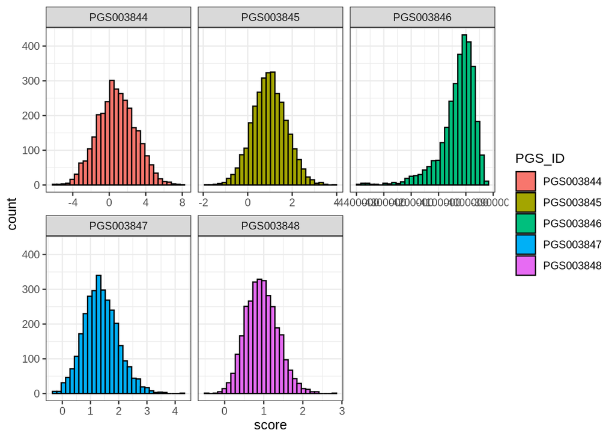

```r
PGS_list <- paste0("PGS00", c(3844:3848))
pgs_scores <- fread("/projects/rpci/wchs/pnfioric/pgs_wchs/WCHS_BrCa_pgs/WCHS_BrCa_BMI_5_PGS.csv", header = T)
colnames(pgs_scores) <- gsub("PGS_", "", colnames(pgs_scores))

pgs_scores_longer <- pgs_scores %>%
  pivot_longer(
    cols = starts_with("PGS"),
    names_to = "PGS_ID",
    values_to = "score"
  ) %>% as.data.table

ggplot(pgs_scores_longer, aes(x=score, fill = PGS_ID))+
  geom_histogram(color = "black")+
  facet_wrap(~PGS_ID, scales="free_x")+
  theme_bw()
```

## Visualizing Coverage

```r
pgs_coverage <- fread("/projects/rpci/wchs/pnfioric/pgs_wchs/WCHS_BrCa_pgs/PGS.matching.summary_WCHS_BrCa_BMI_PGS.csv")
head(pgs_coverage)
```

```
##        Trait N.of.Variants N.of.non_zero_Variants N.of.Ambg % Ambg
##       <char>         <int>                  <int>     <int>  <num>
## 1: PGS003844            87                     87         0   0.00
## 2: PGS003845        752209                 225012       334   0.04
## 3: PGS003846        817189                 817189        67   0.01
## 4: PGS003847        300864                 300864         0   0.00
## 5: PGS003848        741723                 382148        79   0.01
##    Total.Matched % Total.Matched Flipped.Mathced % Flipped.Matched
##            <int>           <num>           <int>             <int>
## 1:            78           89.66               0                 0
## 2:        215351           95.71               0                 0
## 3:        771884           94.46               0                 0
## 4:        293162           97.44               0                 0
## 5:        361296           94.54               1                 0
```

*Initial Point* (10 January 2026): The coverage of the variants above is far from ideal. The original manuscript reads: “SNPs with $MAF>.0.01$ in at least one population were kept in the analyses.” That means that some of these variants could be somewhat rare in a given population ($MAF<0.05$) and kept in the analysis but near non-existent in another population. These likely would have been filtered out of our analysis with minor allele frequency filtering.

*Updated Point* (4 February 2026): The coverage issues above was resolved by editing the `UKB.PGS_PNF1_BMI.R` and `08_merge.valid.nvar_bmi_PNF.R` scripts. The issue was that variants with zero or NA effect sizes were being removed from the PGS calculation to decrease computing cost. However, after the fact, these variants were not removed from the `% Matched` calculation.

# Troubleshooting

## Example Case: PGS003844

Let’s take a look at how many SNPs match by position and investigate those which do not match. I selected the first PGS because it has the fewest SNPs and may serve as a proof of concept for how this may work.

```r
# Read in list of genotyped SNPs
bim_full <-fread("/projects/rpci/wchs/pnfioric/geno_filter_WCHS_Merged_0.01_0.3_AABC_AMBER_FULL/wchs_geno002_full.bim")
pgs <- fread(weight_dir %&% "../bmi_weights/PGS003844.txt", header = T)

# Define by position and chromosome
bim_full$cpos <- paste0(bim_full$V1, ":", bim_full$V4)
pgs$cpos <- paste0(pgs$chr_name, ":", pgs$chr_position)

# Filter to identify missing SNPs
table(pgs$cpos %in% bim_full$cpos)
```

```
##
## FALSE  TRUE
##     9    78
```

```r
pgs_miss <- pgs %>% filter(!cpos %in% bim_full$cpos)
head(pgs_miss)
```

```
##          rsID chr_name chr_position effect_allele other_allele effect_weight
##        <char>    <int>        <int>        <char>       <char>         <num>
## 1: rs11885334        2     56649249             C            T      0.438482
## 2: rs13400734        2    162663538             T            C      0.426416
## 3:  rs1121600       16     35523541             T            C      1.427930
## 4:  rs6478760        9    126840467             A            G      0.350191
## 5:  rs2405433        4    153682144             T            C      0.461773
## 6:   rs818898        9      6970806             G            A     -0.393631
##           cpos
##         <char>
## 1:  2:56649249
## 2: 2:162663538
## 3: 16:35523541
## 4: 9:126840467
## 5: 4:153682144
## 6:   9:6970806
```

Above we can see a list of SNPs that are not found within the genotypes. If we look up some of these SNPs, we can find a situation that is surprising since many of these SNPs are somewhat common.

# Check position coverage of variants

```r
weight_dir <- "/projects/rpci/wchs/pnfioric/pgs_wchs/WCHS_BrCa_pgs/pgs_weights/bmi_weights/"
file_list <- list.files(weight_dir,pattern =  "(*.).txt")
pgs_match <- data.table()

strand_flip <- function(a) {
  chartr("ACGT", "TGCA", a)
}


bim_dt<-bim_full
setnames(bim_dt,
         c("V1","V2","V3","V4","V5","V6"),
         c("CHR","rsID_bim","CM","POS","A1","A2"))

bim_dt[, cpos := paste0(CHR, ":", POS)]

bim_dt[, `:=`(
  A1 = toupper(A1),
  A2 = toupper(A2)
)]
pgs_match <- data.table()
for (i in file_list) {
  message("Processing ", i)
  pgs <- fread(file.path(weight_dir, i))
  pgs[, cpos := paste0(chr_name, ":", chr_position)]
  pgs[, `:=`(
    ea = toupper(effect_allele),
    oa = toupper(other_allele)
  )]

  # Merge by position (primary key)
  m <- merge(
    pgs,
    bim_dt,
    by = "cpos",
    suffixes = c("_pgs", "_bim")
  )
  if (nrow(m) == 0) {
    pgs_match <- rbind(
      pgs_match,
      data.table(
        PGS = i,
        N_SNP = nrow(pgs),
        N_pos_match = 0,
        N_allele_match = 0,
        N_strand_match = 0,
        Perc_usable = 0
      )
    )
    next
  }
  ## Direct allele match (any order)
  m[, allele_match :=
      (ea == A1 & oa == A2) |
      (ea == A2 & oa == A1)
  ]

  ## Strand-flipped alleles
  m[, `:=`(
    ea_flip = strand_flip(ea),
    oa_flip = strand_flip(oa)
  )]

  m[, strand_match :=
      (ea_flip == A1 & oa_flip == A2) |
      (ea_flip == A2 & oa_flip == A1)
  ]

  ## Ambiguous SNPs (cannot strand flip safely)
  m[, ambiguous :=
      (ea %in% c("A","T") & oa %in% c("A","T")) |
      (ea %in% c("C","G") & oa %in% c("C","G"))
  ]

  ## Valid usable variants
  m[, usable := allele_match | (strand_match & !ambiguous)]

  ## Align effect weights
  m[, effect_weight_aligned :=
      fifelse(
        allele_match,
        effect_weight,
        fifelse(strand_match & !ambiguous, -effect_weight, NA_real_)
      )
  ]

  ## Summaries
  pgs_match <- rbind(
    pgs_match,
    data.table(
      PGS = i,
      N_SNP = nrow(pgs),
      N_pos_match = nrow(m),
      N_allele_match = sum(m$allele_match),
      N_strand_match = sum(m$strand_match & !m$ambiguous),
      N_ambiguous = sum(m$ambiguous),
      Perc_usable = 100 * sum(m$usable) / nrow(pgs)
    )
  )
}
```

```
## Processing PGS003844.txt
```

```
## Processing PGS003845.txt
```

```
## Processing PGS003846.txt
```

```
## Processing PGS003847.txt
```

```
## Processing PGS003848.txt
```

```r
head(pgs_match)
```

```
##              PGS  N_SNP N_pos_match N_allele_match N_strand_match N_ambiguous
##           <char>  <int>       <int>          <int>          <int>       <int>
## 1: PGS003844.txt     87          78             78              0           0
## 2: PGS003845.txt 752209      720420         719884              0         193
## 3: PGS003846.txt 817189      772503         771884              0          38
## 4: PGS003847.txt 300864      293168         293162              0           0
## 5: PGS003848.txt 741723      699291         698952              1          21
##    Perc_usable
##          <num>
## 1:    89.65517
## 2:    95.70266
## 3:    94.45599
## 4:    97.44004
## 5:    94.23370
```

## Identifying the problem

The reason for this may be that most of these variants have VERY low effect sizes. i.e. zero effect.

For example, let’s take a look at the PGS003845 downloaded from the PGS catalog for hg37.

```
rsID    chr_name        chr_position    effect_allele   other_allele    effect_weight   hm_source       hm_rsID hm_chr  hm_pos  hm_inferOtherAllele
rs10000008      4       172776204       T       C       0.0     ENSEMBL rs10000008      4       171855053
rs10000011      4       138223055       T       C       0.0     ENSEMBL rs10000011      4       137301901
rs1000002       3       183635768       T       C       0.0     ENSEMBL rs1000002       3       183917980
rs1000003       3       98342907        G       A       0.0     ENSEMBL rs1000003       3       98624063
rs10000030      4       103374154       A       G       0.0     ENSEMBL rs10000030      4       102452997
rs1000007       2       237752054       C       T       -0.000165605867044904   ENSEMBL rs1000007       2       236843411
```

## Adding WCHS IDs to Genotype labels on PGS

```r
pgs.dir <- "/projects/rpci/wchs/pnfioric/pgs_wchs/WCHS_BrCa_pgs/"
ID_key <- read_xlsx("/projects/rpci/wchs/pnfioric/pgs_wchs/AABCGS_WCHS_IDs.xlsx")

PGS_total<-fread(pgs.dir %&% "WCHS_BrCa_BMI_5_PGS.csv", header = T) %>%
  mutate(Abridged_Genotype_ID=sub("_.*$", "", samples))

PGS_matched<-left_join(PGS_total,ID_key,  by = c("Abridged_Genotype_ID"="AABCGS_ID")) %>%
  select(Genotype_ID=samples, WCHS_ID, AABC_ID, Abridged_Genotype_ID_AABCGS_ID= Abridged_Genotype_ID, starts_with("PGS"))
fwrite(PGS_matched, pgs.dir %&% "WCHS_BrCa_BMI_5_PGS_with_WCHS_IDs.csv", col.names = T, row.names = F, sep= ",", quote = F)
```